# Minicurso_sia

Lino Carvalho

2023-10-18

## Vamos iniciar

### Esse documento está sendo escrito em **R-Markdown**

### Segue abaixo as variáveis que estão no conjunto de dados.

```r
library(readxl)
Turma_estudantes <- read_excel("Turma_estudantes.xlsx")

str(Turma_estudantes)
```

```
## tibble [20 × 8] (S3: tbl_df/tbl/data.frame)
##  $ Aluno    : chr [1:20] "Eduardo" "Isabela" "Pedro" "Rafaela" ...
##  $ Sexo     : chr [1:20] "M" "F" "M" "F" ...
##  $ Idade    : num [1:20] 20 23 26 21 19 25 35 24 25 20 ...
##  $ Altura   : num [1:20] 1.9 1.72 1.84 1.55 1.57 1.65 1.69 1.86 1.84 1.59 ...
##  $ Peso     : num [1:20] 90 67 82 67 55 52 60 75 80 54 ...
##  $ Ingles   : chr [1:20] "Avançado" "Basico" "Basico" "Intermediario" ...
##  $ Bairro   : chr [1:20] "A" "E" "D" "C" ...
##  $ Nº Irmãos: num [1:20] 2 1 3 2 2 1 3 2 1 3 ...
```

#### O que são essas informações de saída do nosso código? obs. vou repetir [1] para informar as saídas.

- [1] 20 total de **linhas** do conjunto de dados, são as observações, objeto dos cursos de estatística
- [1] 8 total de **colunas** do conjunto de dados, são as variáveis ou atributos, objeto dos cursos de estatística.

OBS. Imaginem, você sendo responsável por informar coisas sobre a turma a partir desse conjunto de dados **Turma_estudantes** será que é possível informar algo ou prof. dessa turma que seja relevante para que o resultados dos alunos que estão no nível básico e intermediário avancem para o nível avançado? Acho que primeiro é necessário conhecer um pouco desses dados, não acham?

# ESTATÍSTICAS DESCRITIVAS UNIVARIADAS:

## vamos conhecer algumas opções de código para ESTATÍSTICA DESCRITIVA - de variáveis QUALITATIVAS

1. A segunda será o Inglês, categorias a variável inglês tem, quantas pessoas tem em cada uma e qual o percentual de pessoas que tem em cada, resumindo:
- categorias na variável inglês;
- totais de pessoas nas categorias;
- percentuais totais nas categorias.

#### 1.1.1 Vamos observar a tabela de contingência da frequência absoluta, o data.frame(table())

```r
data.frame(table(Turma_estudantes$Ingles))
```

```
##            Var1 Freq
## 1      Avançado    7
## 2        Basico    7
## 3 Intermediario    6
```

```r
data.frame(proportions(table(Turma_estudantes$Ingles))*100)
```

```
##            Var1 Freq
## 1      Avançado   35
## 2        Basico   35
## 3 Intermediario   30
```

#### 1.2 vamos observar os gráficos de barra a partir da proporção, que é comummente chamado frequência relativa, o barplot(proportions(table()))

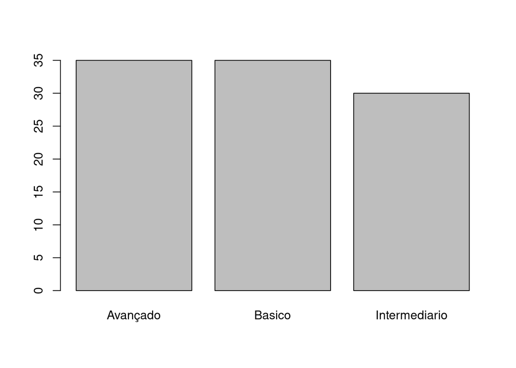

```r
barplot(proportions(table(Turma_estudantes$Ingles))*100)
```

#### 1.3 vamos observar os gráficos de barra só da contagem, que é comummente chamado frequência absoluta, o barplot(table()).

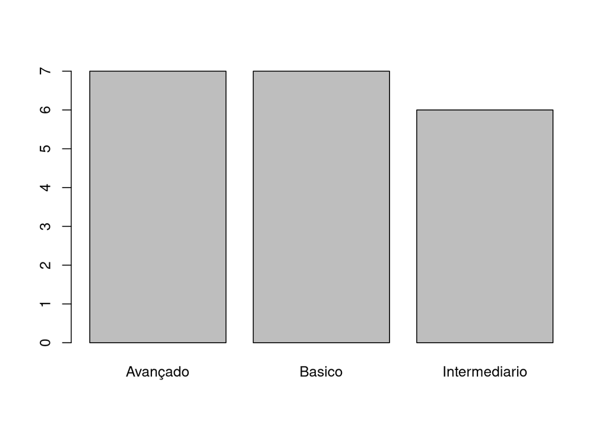

```r
barplot(table(Turma_estudantes$Ingles))
```

##### 1.3 Como exercício façam o mesmo caminho para variável **Sexo**, serão duas saídas gráficas: relativa (código proportions) e absoluta (table). Quais resultados teremos?

##### 1.4 Façam como exercício a variável Bairro, em quais bairros os estudantes moram, quantos moram em cada bairro, resumindo:

- Total de bairros e estudantes por bairro
- percentual de estudantes por bairro.

## vamos conhecer algumas opções de código para ESTATÍSTICA DESCRITIVA - de variáveis QUANTITATIVAS

Qual o resumo das idades dos estudantes: obs. Com o código summary(nome_do_conjunto_de_dados$coluna_[precisar ser de dados quantitativos])

obs2. a saída: Min : o menor valor do vetor 1st Qu: é o quartil de 25% do conjunto. objeto dos cursos de estatística Median: é a mediana do conjunto, objeto dos cursos de estatística 3rd Qu: é o quartil de 75% do conjunto, objeto dos cursos de estatística Max: o maior valor do vetor

```r
summary(Turma_estudantes$Idade)
```

```
##    Min. 1st Qu.  Median    Mean 3rd Qu.    Max.
##   19.00   20.00   22.50   22.95   25.00   35.00
```

Vamos informar separadamente as informações da Idade como média, variância e desvio padrão

```r
mean(Turma_estudantes$Idade)
```

```
## [1] 22.95
```

```r
var(Turma_estudantes$Idade)
```

```
## [1] 14.15526
```

```r
sd(Turma_estudantes$Idade)
```

```
## [1] 3.762348
```

Qual a distribuição visual, pelo **histograma**, das idades dos estudantes dessa turma?

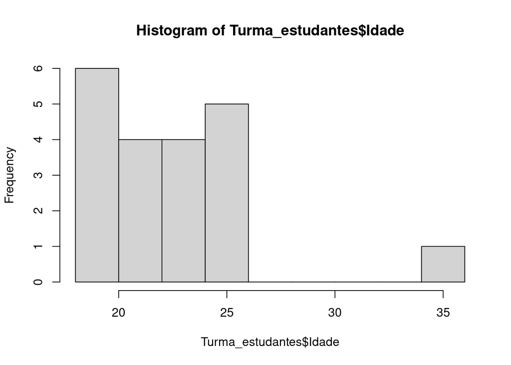

```r
hist(Turma_estudantes$Idade)
```

# ESTATÍSTICAS DESCRITIVAS BIVARIADAS:

## variáveis Qualitativas vs Qualitativas:

##### Resumo: Em análise bidimensional, em variáveis qualitativas, os dados são resumidos em –tabelas de duplas entrada–, onde as saídas das tabelas de contingência ou os gráficos são as frequências absolutas ou relativas que pertencem as categorias de uma e da outra variável. Um dos principais objetivos é conhecer o grau de dependência entre elas, de modo que possamos prever melhor o resultado de uma delas a partir da realização da outra.

#### Obs. As estatísticas descritivas Bivariadas buscam entender a existência de associação entre duas variáveis, como a mudança de opinião de certo comportamento de uma variável na presença ou não de informação sobre a segunda variável.

- Relacionar duas variáveis qualitativas ou categóricas, as relações que mais comumente são estudadas são:
  1. Frequências absolutas:
  - por linha, que é em relação ao total de linhas.
  - por coluna, que é em relação ao total de colunas.
  2. Frequências Relativas (%):
  - por linha, que é em relação ao total de linhas.

## por coluna, que é em relação ao total de colunas.

1. Serão as variáveis: Sexo vs Ingles, as saídas serão: **(a)** e **(b)**

```r
# no absoluto como pode ser visto os totais linha e colunas estão informados
tabela_sexo_ingles <- table(Turma_estudantes$Sexo, Turma_estudantes$Ingles)
tabela_sexo_ingles
```

```
##
##     Avançado Basico Intermediario
##   F        2      5             4
##   M        5      2             2
```

1. Nessa tabela temos as mesmas saídas que na tabela anterior mas as proporções totais são as linhas, no código se escolhe pelo atributo **margin**, que para linha é **1**.

```r
# por linha
round(proportions(table(Turma_estudantes$Sexo, Turma_estudantes$Ingles), margin = 1)*100,2)
```

```
##
##     Avançado Basico Intermediario
##   F    18.18  45.45         36.36
##   M    55.56  22.22         22.22
```

```r
# por coluna
round(proportions(table(Turma_estudantes$Sexo,Turma_estudantes$Ingles), margin = 2)*100,2)
```

```
##
##     Avançado Basico Intermediario
##   F    28.57  71.43         66.67
##   M    71.43  28.57         33.33
```

- Saídas gráficas:

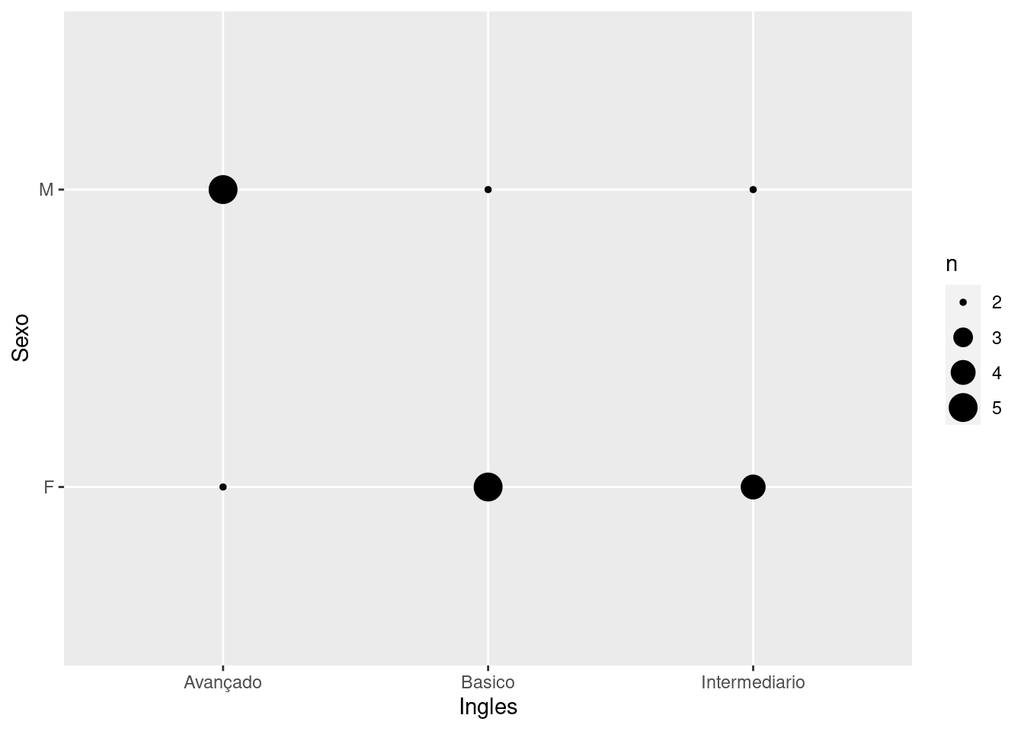

```r
library(ggplot2)
ggplot(data = Turma_estudantes) + geom_count(mapping = aes(x=Ingles, y=Sexo))
```

- Como explico???

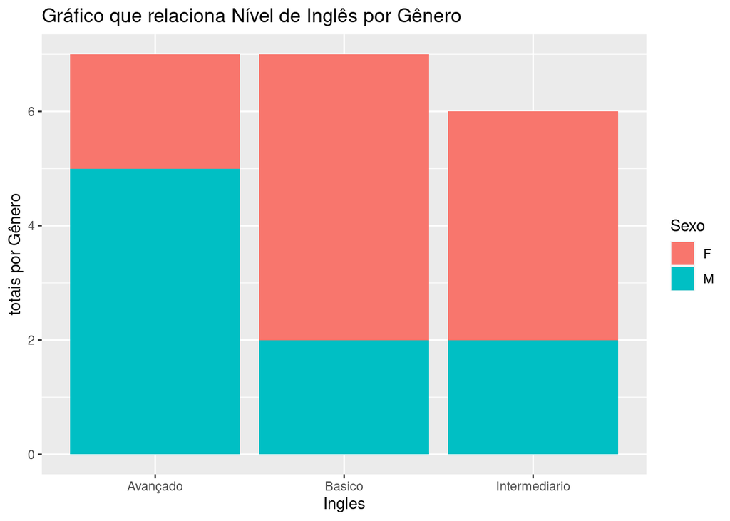

```r
library(ggplot2)
ggplot(Turma_estudantes, aes(Ingles)) + geom_bar(aes(fill=Sexo)) + ylab('totais por Gênero') + labs(
  title = 'Gráfico que relaciona Nível de Inglês por Gênero'
)
```

# Vamos Verificar por meio de testes de Hipótese se essas variáveis possuem associação.

### Qual teste escolher?

1. o Teste Exato de Fisher
2. o Teste Qui Quadrado

##### obs. o teste a ser escolhido será o teste exato de fisher, é o mais indicado para grupos menores que 50 observações, mas não é suficiente, o obs2 informará o que falta.

##### obs2, outra forma de avaliar se a melhor opção é o teste exato de Fisher e verificar se o resultado das células da tabela de contingência é <5 (tem um cálculo específico, mas é um calculo simples), para conjuntos maiores indicamos o teste qui quadrado

```r
c11<-sum(tabela_sexo_ingles[,1])*sum(tabela_sexo_ingles[1,])/sum(tabela_sexo_ingles)
```

- Quais hipóteses?
  1. $H_0$: independência. Se p > 0.05 não rejeita H0
  2. $H_1$: dependência. Se p < 0.05 rejeita H0.

```r
fisher <- fisher.test(tabela_sexo_ingles)
fisher
```

```
##
##  Fisher's Exact Test for Count Data
##
## data:  tabela_sexo_ingles
## p-value = 0.2852
## alternative hypothesis: two.sided
```

#### Conclusão H0 não é rejeitado, já que p-value > 0.05. Isso quer dizer que p > 0.05, então informa que o nível de inglês é independente do gênero, em outras palavras não tem associação entre gênero e nível de inglês.

## Variáveis Quantitativas vs Quantitativas:

##### Resumo: Em análise bidimensional, em variáveis quantitativas, os dados são resumidos em –mensurações e técnicas como gráficos de dispersão ou quantis apropriados–, podemos ter o casos de variáveis quantitativas agrupadas em classes, desse modo, se tem também tabelas de dupla entrada. Mas sempre o objetivo central é encontrar as possíveis relações e/ou associações entre as duas variáveis.

#### Obs. As estatísticas descritivas Bivariadas buscam entender a existência de associação entre duas variáveis, como a –mudança– de opinião de certo comportamento de uma variável na presença ou não de informação sobre a segunda variável.

#### Para essa parte vamos trabalhar com um sub quadro de dados com as variáveis peso e altura, que são variáveis do quadro original

```r
turma_alt_pes <- data.frame(Altura = Turma_estudantes$Altura, Peso = Turma_estudantes$Peso)
```

- Relacionar duas variáveis Quantitativas, será através de gráficos de **Dispersão**

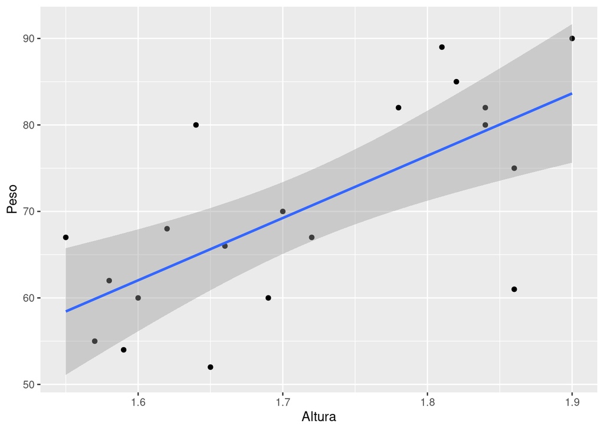

```r
library(ggplot2)
ggplot(turma_alt_pes, aes(Altura, Peso)) + geom_point() + geom_smooth(method = lm)
```

#### Verificando a normalidade de cada um dos dois grupos (Peso e Altura) de forma UNIVARIADA, através do teste de Shapiro-Wilk pelo resultado do p-value, assim se:

- $H_0$: os dados seguem uma distribuição normal, p-value > 0.05
- $H_1$: os dados **não** seguem é uma distribuição normal, p-value < 0.05

```r
shapiro.test(turma_alt_pes$Altura)
```

```
##
##  Shapiro-Wilk normality test
##
## data:  turma_alt_pes$Altura
## W = 0.91833, p-value = 0.09202
```

##### Conclusão pelo resultado do p-value (p > 0.05) não se rejeita H0, e Altura é uma distribuição normal segundo o teste de Shapiro-Wilk.

```r
shapiro.test(turma_alt_pes$Peso)
```

```
##
##  Shapiro-Wilk normality test
##
## data:  turma_alt_pes$Peso
## W = 0.94424, p-value = 0.288
```

### obs. caso o teste de normalidade seja rejeitado, será necessário realizar de correlação de Spearman (teste não paramétrico)

```r
teste_pearson <- cor.test(turma_alt_pes$Altura, turma_alt_pes$Peso, method = "pearson")
teste_pearson
```

```
##
##  Pearson's product-moment correlation
##
## data:  turma_alt_pes$Altura and turma_alt_pes$Peso
## t = 4.0989, df = 18, p-value = 0.0006738
## alternative hypothesis: true correlation is not equal to 0
## 95 percent confidence interval:
##  0.3643209 0.8698788
## sample estimates:
##       cor
## 0.6948226
```

### Conclusão: p-value tem p < 0.05, isso indica que devemos rejeitar H0, agora vamos interpretar a correlação (cor), logo a correlação é positiva e pelo valor cor = 0.69, indica correlação moderada (|0.3|<= cor<= |0.7|).

### Variáveis Qualitativas (quali) vs Quantitativas (quanti):

#### Importante: É necessário avaliar se essas variáveis possuem essas caracteristicas.

1. normalidade - pelo teste de shaspiro
2. homogeneidade de variâncias (em outras palavras: igualdade de variâncias) - pelo teste de Bartlett.
- Tendo atendido essas caracteristicas, seus resultados podem ser avaliados com tranquilidade.

##### Resumo: Em análises bivariadas de variáveis quali x quanti, cabe analisar o que acontece c/ a variável, quantitativa dentro de cada variável qualitativa. Para esse tipo de análise é conviniente contar c/ uma medida que quantifique o grau de dependência entre as variáveis (1)

boxplot(idade~ingles, data - turma_estudantes) tapply (idade, ingles, summary) describe para cada grupo. normalidade

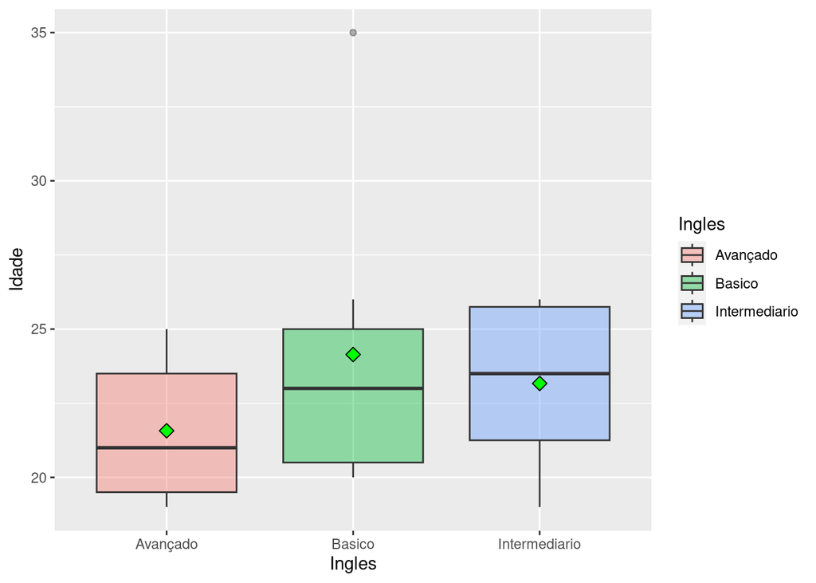

```r
ggplot(Turma_estudantes, aes(Ingles, Idade, fill = Ingles)) +
  geom_boxplot(alpha = 0.4) +
  stat_summary(fun = 'mean', geom = 'point', shape = 23, size = 3, fill = 'green')
```

#### Nessa saída, os pontos da cor verde são as médias dos valores de Idade dentro de cada grupo, e os grupos são os níveis de Ingles, e como podemos observar todas estão dentro das caixas (boxplot), e as medianas são as linhas em preto que dividem as caixas

#### O próximo é verificar se a variavel idade tem distrbuição normal, pelo teste de shapiro.

- $H_0$: os dados seguem uma distribuição normal, p-value > 0.05
- $H_1$: os dados **não** seguem é uma distribuição normal, p-value < 0.05

```r
library(nortest)
#Testes
t1 <- ks.test(Turma_estudantes$Idade, "pnorm", mean(Turma_estudantes$Idade), sd(Turma_estudantes$Idade)) # KS
t2 <- lillie.test(Turma_estudantes$Idade) # Lilliefors
t3 <- cvm.test(Turma_estudantes$Idade) # Cramér-von Mises
t4 <- shapiro.test(Turma_estudantes$Idade) # Shapiro-Wilk
t5 <- sf.test(Turma_estudantes$Idade) # Shapiro-Francia
t6 <- ad.test(Turma_estudantes$Idade) # Anderson-Darling
# Tabela de resultados
testes <- c(t1$method, t2$method, t3$method, t4$method, t5$method,
 t6$method)
estt <- as.numeric(c(t1$statistic, t2$statistic, t3$statistic,
 t4$statistic, t5$statistic, t6$statistic))
valorp <- c(t1$p.value, t2$p.value, t3$p.value, t4$p.value, t5$p.value,
 t6$p.value)
resultados <- cbind(estt, valorp)
rownames(resultados) <- testes
colnames(resultados) <- c("Estatística", "p")
print(resultados, digits = 4)
```

```
##                                                Estatística        p
## One-sample Kolmogorov-Smirnov test                 0.15878 0.694391
## Lilliefors (Kolmogorov-Smirnov) normality test     0.15878 0.206478
## Cramer-von Mises normality test                    0.09769 0.112028
## Shapiro-Wilk normality test                        0.83588 0.003119
## Shapiro-Francia normality test                     0.82414 0.003048
## Anderson-Darling normality test                    0.80371 0.030823
```

##### Agora vamos começar os testes:

1. teste - análise de variância (anova - aov()), ##### obs. a variável quantitativa é a primeira e a qualitativa em segundo

```r
anova_Idade_Ingles <- aov(Idade~Ingles, Turma_estudantes)
anova_Idade_Ingles
```

```
## Call:
##    aov(formula = Idade ~ Ingles, data = Turma_estudantes)
##
## Terms:
##                    Ingles Residuals
## Sum of Squares   23.54524 245.40476
## Deg. of Freedom         2        17
##
## Residual standard error: 3.799418
## Estimated effects may be unbalanced
```

se não normal: teste de kruskal wallis (kruskal.test())

```r
kruskal.test(Idade~Ingles, data = Turma_estudantes)
```

```
##
##  Kruskal-Wallis rank sum test
##
## data:  Idade by Ingles
## Kruskal-Wallis chi-squared = 1.642, df = 2, p-value = 0.44
```

##### Conclusão o teste não rejeita $H_0$, já que p > 0.05.